# 情報科学3

ロジスティック回帰 (2)

矢内 勇生

2021-10-28（改訂: 2021-11-11）

## 準備

必要なパッケージを読み込む。

```r
pacman::p_load(tidyverse,
               broom,
               gmodels,
               caret,
               ROCR)
```

次に、ggplot2のテーマとフォントの設定を行う。自分好みの設定がある場合は自由に変えてよい。

```r
if (.Platform$OS.type == "windows") {
  if (require(fontregisterer)) {
    my_font <- "Yu Gothic"
  } else {
    my_font <- "Japan1"
  }
} else if (capabilities("aqua")) {
  my_font <- "HiraginoSans-W3"
} else {
  my_font <- "IPAexGothic"
}

theme_set(theme_gray(base_size = 9,
                     base_family = my_font))
```

前回同様、説明のために『Rによる計量政治学』（浅野正彦, 矢内勇生. 2018）で使用されているデータ（hr-data.csv） を使う。

```r
HR <- read_csv("data/hr-data.csv")
```

小選挙区での当落を表すダミー変数（これを二値の応答変数として扱う）を作る。

```r
HR <- HR %>%
  mutate(wlsmd = ifelse(wl == "当選", 1, 0))
```

## ロジスティック回帰

### 例：過去の当選回数で当選確率を説明する

2005年のデータを取り出し、候補者の小選挙区における当落 (wlsmd) を縦軸に、それまでの当選回数 (previous) を横軸にした散布図を表示してみよう。

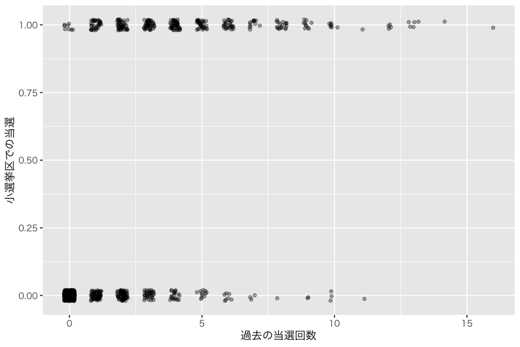

```r
HR2005 <- HR %>%
  filter(year == 2005)
p <- ggplot(HR2005, aes(previous, wlsmd)) +
  geom_jitter(size = 1,
              alpha = 1/3,
              height = 0.02,
              width = 0.2) +
  labs(x = "過去の当選回数",
       y = "小選挙区での当選")
plot(p)
```

このデータを使い、当落を応答変数、過去の当選回数を説明変数として、ロジスティック回帰分析を行おう。

```r
fit <- glm(wlsmd ~ previous,
           data = HR2005,
           family = binomial(link = "logit"))
tidy(fit, conf.int = TRUE) %>%
  select(term, estimate, std.error, conf.low, conf.high)
```

```
## # A tibble: 2 × 5
##   term        estimate std.error conf.low conf.high
##   <chr>          <dbl>     <dbl>    <dbl>     <dbl>
## 1 (Intercept)   -2.34     0.133    -2.61     -2.09
## 2 previous       0.713    0.0475    0.623     0.809
```

この結果を図示しよう。

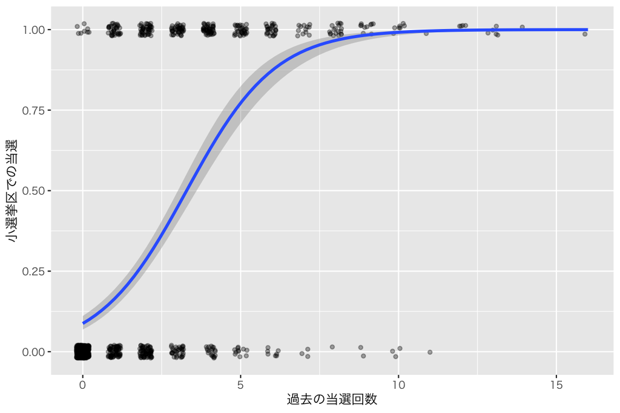

```r
p_fit <- p +
  geom_smooth(method = "glm",
              method.args = list(family = binomial(link = "logit")))
plot(p_fit)
```

次に、成功確率（当選確率）の予測値を求める。

```r
pred <- predict(fit, type = "response")
```

予測確率が0.5以上の候補者を「当選 (1)」に、0.5未満の候補者を「落選 (0)」に分類する。

```r
y_hat <- ifelse(pred >= 0.5, 1, 0)
```

分類結果は、

```r
table(y_hat)
```

```
## y_hat
##   0   1
## 773 216
```

である。

### 分類性能の評価

この分類の性能を確認するために、混同行列 (confusion matrix) を作る。 `gmodels::CrossTable()` で作れる。

```r
CrossTable(x = HR2005$wlsmd,
           y = y_hat,
           dnn = c("実際の当落", "当落の予測"),
           prop.r = FALSE,　# 行%は表示しない
           prop.c = FALSE,　# 列%は表示しない
           prop.t = TRUE,   # 合計%は表示する
           prop.chisq = FALSE) # chi^2値は表示しない
```

```
##
##
##    Cell Contents
## |-------------------------|
## |                       N |
## |         N / Table Total |
## |-------------------------|
##
##
## Total Observations in Table:  989
##
##
##              | 当落の予測
##   実際の当落 |         0 |         1 | Row Total |
## -------------|-----------|-----------|-----------|
##            0 |       641 |        48 |       689 |
##              |     0.648 |     0.049 |           |
## -------------|-----------|-----------|-----------|
##            1 |       132 |       168 |       300 |
##              |     0.133 |     0.170 |           |
## -------------|-----------|-----------|-----------|
## Column Total |       773 |       216 |       989 |
## -------------|-----------|-----------|-----------|
##
##
```

この混同行列から、以下のことがわかる。

- 真陰性の個体数は641
- 偽陽性の個体数は48
- 偽陰性の個体数は132
- 真陽性の個体数は168

また、

- 真陰性率は0.648
- 偽陽性率は0.049
- 偽陰性率は0.133
- 真陽性率は0.170

これらの値は、自分で計算することもできる。

```r
(TN <- sum(HR2005$wlsmd == 0 & y_hat == 0)) # 真陰性数
```

```
## [1] 641
```

```r
(FP <- sum(HR2005$wlsmd == 0 & y_hat == 1)) # 偽陽性数
```

```
## [1] 48
```

```r
(FN <- sum(HR2005$wlsmd == 1 & y_hat == 0)) # 偽陰性数
```

```
## [1] 132
```

```r
(TP <- sum(HR2005$wlsmd == 1 & y_hat == 1)) # 真陽性数
```

```
## [1] 168
```

```r
(TNR <- mean(HR2005$wlsmd == 0 & y_hat == 0)) # 真陰性率
```

```
## [1] 0.6481294
```

```r
(FPR <- mean(HR2005$wlsmd == 0 & y_hat == 1)) # 偽陽性率
```

```
## [1] 0.04853387
```

```r
(FNR <- mean(HR2005$wlsmd == 1 & y_hat == 0)) # 偽陰性率
```

```
## [1] 0.1334681
```

```r
(TPR <- mean(HR2005$wlsmd == 1 & y_hat == 1)) # 真陽性率
```

```
## [1] 0.1698686
```

これらの値を元に、いくつかの評価指標を確認してみよう。 まず、正解率（正確度）は、

```r
TPR + TNR
```

```
## [1] 0.817998
```

```r
#(TP + TN) / (TP + TN + FP + FN) # これと同じ
```

である。正解率はそれなり高そうである。（当選者よりも落選者のほうが多いので）全員を落選に分類すれば、

```r
mean(HR2005$wlsmd == 0)
```

```
## [1] 0.6966633
```

すなわち約70％の正解率になる。ロジスティック回帰を使うことによって正解率が約12ポイント上昇している。

次に、適合率は、

```r
TP / (TP + FP)
```

```
## [1] 0.7777778
```

であり、「当選」と分類されたが実際には落選する候補者が22%ほどいることがわかる。

真陽性率（感度）は、

```r
TP / (TP + FN)
```

```
## [1] 0.56
```

であり、実際に当選した候補者のうち、44%が誤って落選に分類されていることがわかる。つまり、感度は高くない。

偽陽性率は、

```r
FP / (TN + FP)
```

```
## [1] 0.06966618
```

であり、落選した候補者のうち誤って当選に分類されるのは7%未満である。特異度は、

```r
1 - FP / (TN + FP)
```

```
## [1] 0.9303338
```

であり、高いと言えるだろう。

感度 (sensitivity) と特異度 (specificity) は、**caret** パッケージの`confusionMatrix()` で混同行列を作ると自動的に計算される。 ただし、この関数を使うためにはラベルを `factor` 型にする必要がある。さらに、`positive` 引数で陽性のラベルを指定する。実際の値が列に、予測が行に表示されるので注意されたい。

```r
confusionMatrix(reference = as.factor(HR2005$wlsmd),
                data = as.factor(y_hat),
                positive = "1")
```

```
## Confusion Matrix and Statistics
##
##           Reference
## Prediction   0   1
##          0 641 132
##          1  48 168
##
##                Accuracy : 0.818
##                  95% CI : (0.7925, 0.8416)
##     No Information Rate : 0.6967
##     P-Value [Acc > NIR] : < 2.2e-16
##
##                   Kappa : 0.5324
##
##  Mcnemar's Test P-Value : 6.153e-10
##
##             Sensitivity : 0.5600
##             Specificity : 0.9303
##          Pos Pred Value : 0.7778
##          Neg Pred Value : 0.8292
##              Prevalence : 0.3033
##          Detection Rate : 0.1699
##    Detection Prevalence : 0.2184
##       Balanced Accuracy : 0.7452
##
##        'Positive' Class : 1
##
```

F値は

```r
(2 * TP) / (2 * TP + FP + FN)
```

```
## [1] 0.6511628
```

である。

最後に、ROC曲線を描いてみよう。**ROCR** パッケージを利用する。

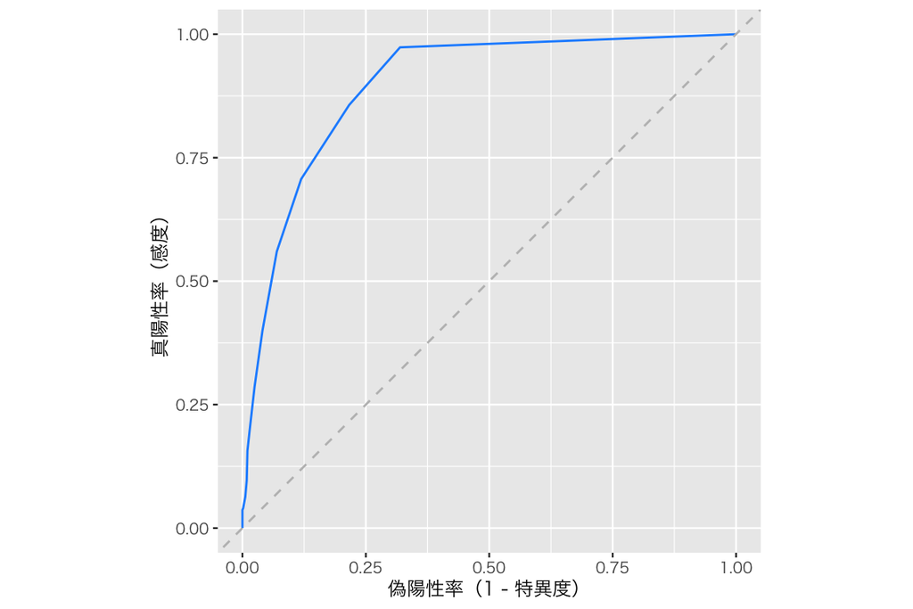

```r
#pred <- predict(fit, type = "response") # 上で実行済み
pr <- prediction(pred, labels = HR2005$wlsmd == 1)
roc <- performance(pr, measure = "tpr", x.measure = "fpr")

df_roc <- tibble(fpr = roc@x.values[[1]],
                 tpr = roc@y.values[[1]])

ROC <- ggplot(df_roc, aes(x = fpr, y = tpr)) +
  geom_line(color = "dodgerblue") +
  geom_abline(color = "gray",
              linetype = "dashed") +
  labs(x = "偽陽性率（1 - 特異度）",
       y = "真陽性率（感度）") +
  coord_fixed()
plot(ROC)
```

モデルがない場合に比べれば、それなりに役立つ予測ができそうだということがわかる。

AUCは、

```r
auc <- performance(pr, measure = "auc")
auc@y.values[[1]]
```

```
## [1] 0.8965094
```

である。慣例に従えば、「良い」モデルだと言えそうだ。

## ロジスティック回帰による分類

浅野・矢内 (2018) の衆院選データには、1996 年から2017年までの8回の衆院選データが含まれている。 1996年から2009年までの5回分のデータを使って学習を行い、2012年の小選挙区で当落を予測（分類）してみよう（2014年と2017年の選挙費用データが欠測なので、これらの年は使わない）。

### データの準備

以下のモデルで選挙費用を利用するので、選挙費用が欠測になっている観測値をあらかじめ取り除く。また、自民党 (LDP) に所属 することを示すダミー変を数を作る。

```r
HR_sub <- HR %>%
  filter(!is.na(expm)) %>%
  mutate(LDP = ifelse(party == "LDP", 1, 0))
```

訓練データ（2009年まで）と検証データ（2012年）を用意する。

```r
HR_train <- HR_sub %>%
  filter(year < 2012)
HR_test <- HR_sub %>%
  filter(year == 2012)
```

### モデル

以下の4つのロジスティック回帰モデルを考える。
$$\begin{align}
\mathrm{logit}(\theta)_n & = \beta_0 + \beta_1 \mathrm{選挙費用}_n \\
\mathrm{logit}(\theta)_n & = \gamma_0 + \gamma_1 \mathrm{過去の当選回数}_n \\
\mathrm{logit}(\theta)_n & = \tau_0 + \tau_1 \mathrm{選挙費用}_n + \tau_2 \mathrm{過去の当選回数}_n\\
\mathrm{logit}(\theta)_n & = \lambda_0 + \lambda_1 \mathrm{選挙費用}_n + \lambda_2 \mathrm{過去の当選回数}_n + \lambda_3 \mathrm{自民党ダミー}_n\\
\end{align}$$

これらのモデルを使い、訓練データでロジスティック回帰の係数を推定する。

```r
models <- alist(
  model1 = wlsmd ~ expm,
  model2 = wlsmd ~ previous,
  model3 = wlsmd ~ expm + previous,
  model4 = wlsmd ~ expm + previous + LDP) %>%
  map(formula)

fits <- models %>%
  map(.f = glm,
      data = HR_train,
      family = binomial(link = "logit"))
```

推定された係数を利用して、検証データ（2012年）の小選挙区での当落の予測確率を計算する。

```r
preds <- fits %>%
  map(.f = predict,
      newdata = HR_test,
      type = "response")
```

予測確率を利用して分類を行う。

```r
y_hat_1 <- ifelse(preds$model1 >= 0.5, 1, 0)
y_hat_2 <- ifelse(preds$model2 >= 0.5, 1, 0)
y_hat_3 <- ifelse(preds$model3 >= 0.5, 1, 0)
y_hat_4 <- ifelse(preds$model4 >= 0.5, 1, 0)
```

モデル1の混同行列を表示する。

```r
CrossTable(x = HR_test$wlsmd,
           y = y_hat_1,
           dnn = c("実際の当落", "当落の予測"),
           prop.r = FALSE,
           prop.c = FALSE,
           prop.t = TRUE,
           prop.chisq = FALSE)
```

```
##
##
##    Cell Contents
## |-------------------------|
## |                       N |
## |         N / Table Total |
## |-------------------------|
##
##
## Total Observations in Table:  1280
##
##
##              | 当落の予測
##   実際の当落 |         0 |         1 | Row Total |
## -------------|-----------|-----------|-----------|
##            0 |       967 |        16 |       983 |
##              |     0.755 |     0.013 |           |
## -------------|-----------|-----------|-----------|
##            1 |       262 |        35 |       297 |
##              |     0.205 |     0.027 |           |
## -------------|-----------|-----------|-----------|
## Column Total |      1229 |        51 |      1280 |
## -------------|-----------|-----------|-----------|
##
##
```

モデル2の混同行列。

```r
CrossTable(x = HR_test$wlsmd,
           y = y_hat_2,
           dnn = c("実際の当落", "当落の予測"),
           prop.r = FALSE,
           prop.c = FALSE,
           prop.t = TRUE,
           prop.chisq = FALSE)
```

```
##
##
##    Cell Contents
## |-------------------------|
## |                       N |
## |         N / Table Total |
## |-------------------------|
##
##
## Total Observations in Table:  1280
##
##
##              | 当落の予測
##   実際の当落 |         0 |         1 | Row Total |
## -------------|-----------|-----------|-----------|
##            0 |       915 |        68 |       983 |
##              |     0.715 |     0.053 |           |
## -------------|-----------|-----------|-----------|
##            1 |       153 |       144 |       297 |
##              |     0.120 |     0.113 |           |
## -------------|-----------|-----------|-----------|
## Column Total |      1068 |       212 |      1280 |
## -------------|-----------|-----------|-----------|
##
##
```

モデル3の混同行列。

```r
CrossTable(x = HR_test$wlsmd,
           y = y_hat_3,
           dnn = c("実際の当落", "当落の予測"),
           prop.r = FALSE,
           prop.c = FALSE,
           prop.t = TRUE,
           prop.chisq = FALSE)
```

```
##
##
##    Cell Contents
## |-------------------------|
## |                       N |
## |         N / Table Total |
## |-------------------------|
##
##
## Total Observations in Table:  1280
##
##
##              | 当落の予測
##   実際の当落 |         0 |         1 | Row Total |
## -------------|-----------|-----------|-----------|
##            0 |       942 |        41 |       983 |
##              |     0.736 |     0.032 |           |
## -------------|-----------|-----------|-----------|
##            1 |       188 |       109 |       297 |
##              |     0.147 |     0.085 |           |
## -------------|-----------|-----------|-----------|
## Column Total |      1130 |       150 |      1280 |
## -------------|-----------|-----------|-----------|
##
##
```

モデル4の混同行列。

```r
CrossTable(x = HR_test$wlsmd,
           y = y_hat_4,
           dnn = c("実際の当落", "当落の予測"),
           prop.r = FALSE,
           prop.c = FALSE,
           prop.t = TRUE,
           prop.chisq = FALSE)
```

```
##
##
##    Cell Contents
## |-------------------------|
## |                       N |
## |         N / Table Total |
## |-------------------------|
##
##
## Total Observations in Table:  1280
##
##
##              | 当落の予測
##   実際の当落 |         0 |         1 | Row Total |
## -------------|-----------|-----------|-----------|
##            0 |       946 |        37 |       983 |
##              |     0.739 |     0.029 |           |
## -------------|-----------|-----------|-----------|
##            1 |       168 |       129 |       297 |
##              |     0.131 |     0.101 |           |
## -------------|-----------|-----------|-----------|
## Column Total |      1114 |       166 |      1280 |
## -------------|-----------|-----------|-----------|
##
##
```

それぞれのモデルについて、ROC曲線を表示する。

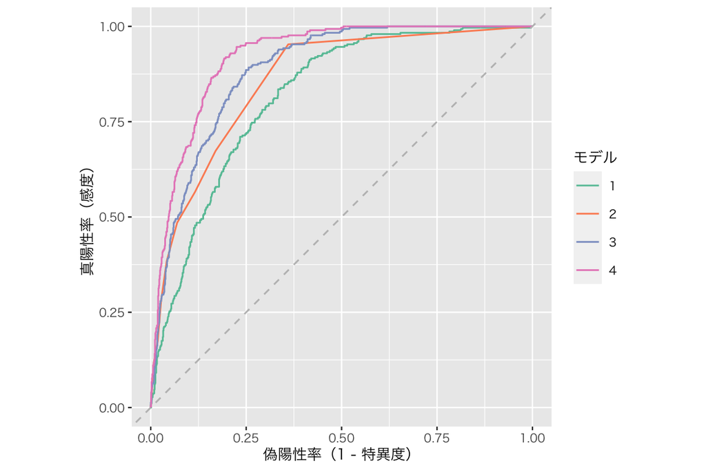

```r
prs <- preds %>%
  map(.f = prediction,
      labels = HR_test$wlsmd == 1)
rocs <- prs %>%
  map(.f = performance,
      measure = "tpr",
      x.measure = "fpr")

fprs <- list(
  fpr_1 = rocs$model1@x.values[[1]],
  fpr_2 = rocs$model2@x.values[[1]],
  fpr_3 = rocs$model3@x.values[[1]],
  fpr_4 = rocs$model4@x.values[[1]])

tprs <- list(
  tpr_1 = rocs$model1@y.values[[1]],
  tpr_2 = rocs$model2@y.values[[1]],
  tpr_3 = rocs$model3@y.values[[1]],
  tpr_4 = rocs$model4@y.values[[1]])

roc_lengths <- sapply(fprs, length)

df_rocs <- tibble(
  fpr = unlist(fprs),
  tpr = unlist(tprs),
  model = factor(rep(1:4, times = roc_lengths))
)

ROCs <- ggplot(df_rocs, aes(x = fpr, y = tpr, color = model)) +
  geom_line() +
  geom_abline(color = "gray",
              linetype = "dashed") +
  labs(x = "偽陽性率（1 - 特異度）",
       y = "真陽性率（感度）") +
  scale_color_brewer(palette = "Set2",
                     name = "モデル") +
  coord_fixed()
plot(ROCs)
```

モデル4の分類性能が最も高そうだということがわかる。

AUCを計算してみよう。

```r
aucs <- prs %>%
  map(.f = performance,
      measure = "auc")

cbind(aucs$model1@y.values[[1]],
      aucs$model2@y.values[[1]],
      aucs$model3@y.values[[1]],
      aucs$model4@y.values[[1]])
```

```
##           [,1]      [,2]      [,3]      [,4]
## [1,] 0.8174505 0.8582005 0.8859449 0.9201476
```

モデル4のAUCが0.9を超えており、「とても良い」分類ができていると考えられる。 ただし、このモデルが2012年以外の選挙をうまく予測できるとは限らない。

**実習課題**

- それぞれのモデルについて、以下の評価指標を計算しなさい。
  - 正解率（正確度）
  - 適合率
  - 真陽性率（感度）
  - 特異度 (1 - 偽陽性率)
  - F値（F1スコア）

授業の内容に戻る